# Lab 3

Jacob Baalson, Charlie Whiting GitHub: jbaalson, chrlwhtng

2/25/2020

```r
dat <- readxl::read_xls('GSS.xls')
names(dat) <- c('Year','Happiness', 'Party', 'Earners', 'Race','Sex','Age', 'Children', 'Marital', 'ID', 'Ballot')
```

1.)

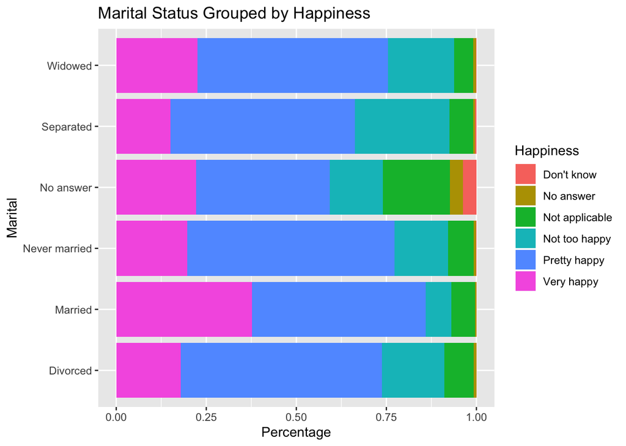

```r
library(ggplot2)

dat <- dat[!is.na(dat$Marital), ]
dat <- dat[!is.na(dat$Happiness), ]

ggplot(dat, aes(x= Marital, fill= Happiness)) + geom_bar(position = "fill") + ggtitle("Marital Status Grouped by Happiness") + coord_flip() + ylab("Percentage")
```

Married people had the highest rate of very happy or pretty happy people. This was followed by those that were never married. People that were seperated had the highest rate of being not too happy. The highest rate of a respondent having not applicable as their happiness rating was those who answered ‘No answer’ for Marital Status.

2.)

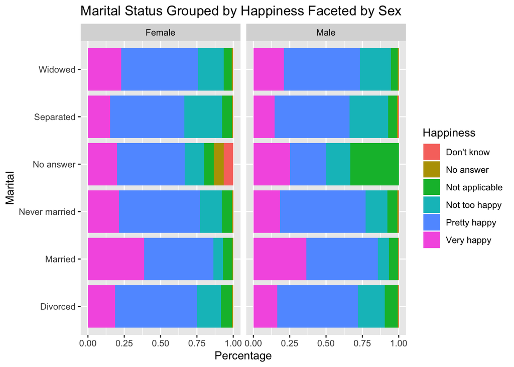

```r
ggplot(dat, aes(x= Marital, fill= Happiness)) + geom_bar(position = "fill") +
  ggtitle("Marital Status Grouped by Happiness Faceted by Sex") + facet_wrap(~Sex) +
  coord_flip() + ylab("Percentage")
```

The level of happiness does not differ greatly between males and females of the same marital status. The one major difference between the charts seperated by sex is in the marital status category named “no answer”. In this category women appear to be more happy than their male counterparts. However, they are also responsible for most of the “Don’t Know” category in the full sample chart.

3.)

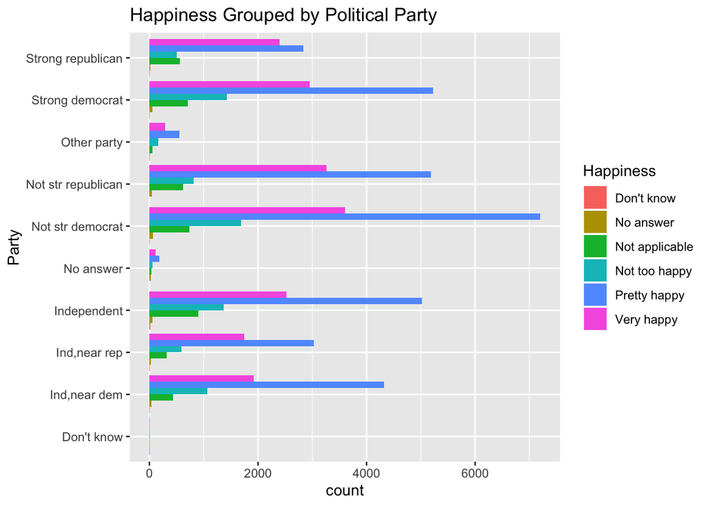

```r
ggplot(dat, aes(x=Party, fill=Happiness)) + geom_bar(position='dodge') +
  coord_flip() + ggtitle("Happiness Grouped by Political Party")
```

4.) How has happiness between males and females changed over time?

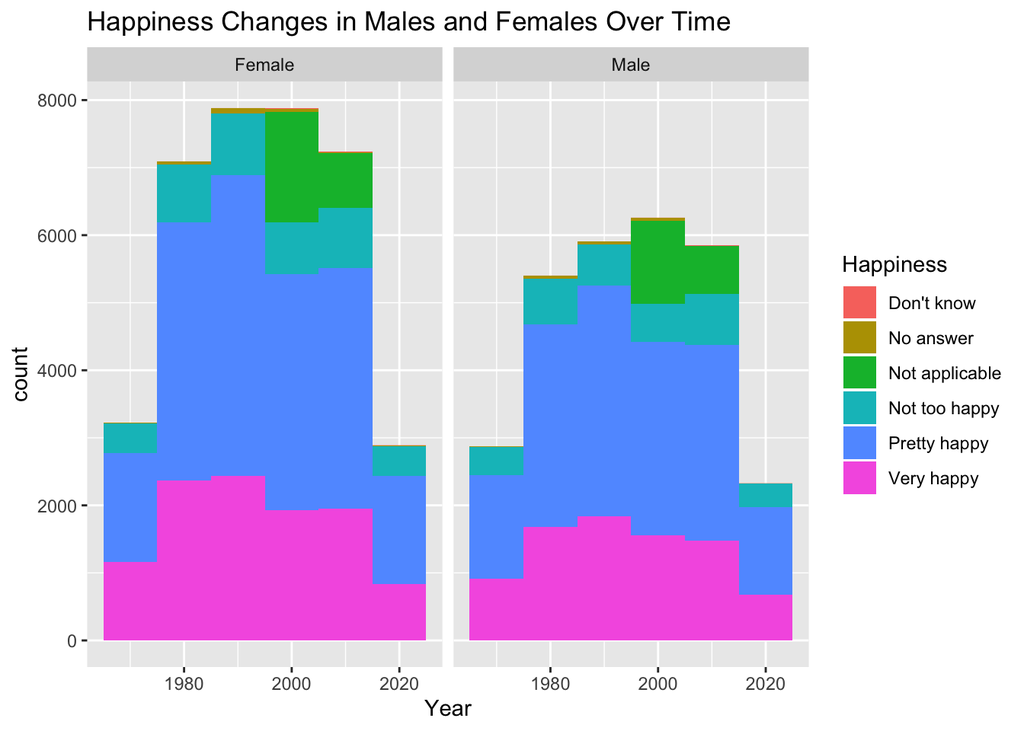

```r
ggplot(dat, aes(x=Year, fill=Happiness)) + geom_histogram(binwidth=10) +
  facet_grid(~Sex) + ggtitle("Happiness Changes in Males and Females Over Time")
```

5.) How do happiness levels vary between males and females dependent on the number of children the respondent has?

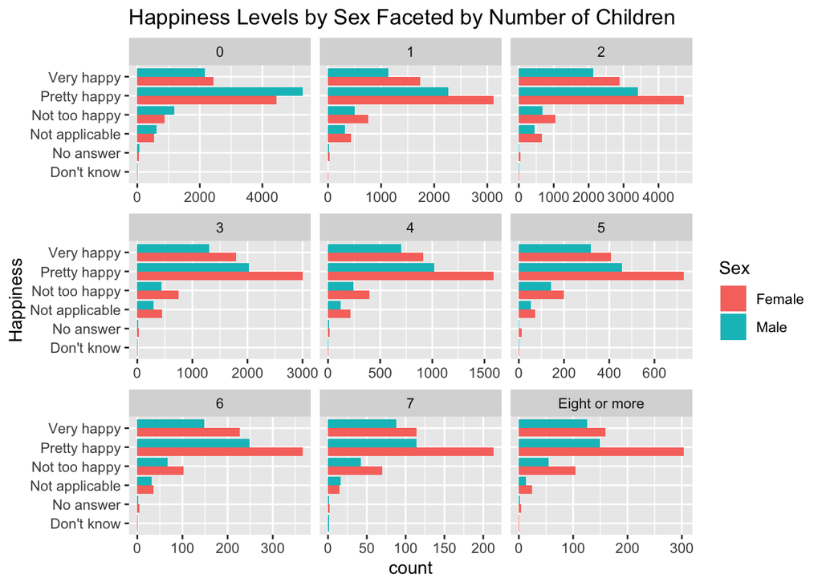

```r
dat4 <- dat[dat$Children != 'Dk na', ]
ggplot(dat4, aes(x= Happiness, fill = Sex)) +
  geom_bar(position = "dodge") + facet_wrap(~Children, scale = 'free_x') +
  coord_flip() +ggtitle("Happiness Levels by Sex Faceted by Number of Children")
```

Females that have zero children seemed to report at a lower rate that they were ‘Not too happy’ than with any other amount of children. This was not the same for males, as the lowest rate of reporting being ‘Not too happy’ was when the respondent had 2 children. Males seemed answer ‘Very Happy’ at around the same rate for all the different number of children they could have while females were ‘Very happy’ at a higher rate when they had 6 children. Males tended to answer ‘Pretty happy’ at the highest rate when they had zero children. Females tended to answer ‘Pretty Happy’ at the same rate throughout almost all all the different numbers of children, except for when they had 0 children. Overall I believe that this chart illustrates that the number of children a female respondent has does not affect their happiness level drastically as long as they have 1 child or more. With Males this chart seems to show that as the amount of children the respondent has increases their overall happiness (‘Pretty Happy’ and ‘Very Happy’ combined) seems to decrease.

6.)Does gender or being married or not affect a respondents political party?

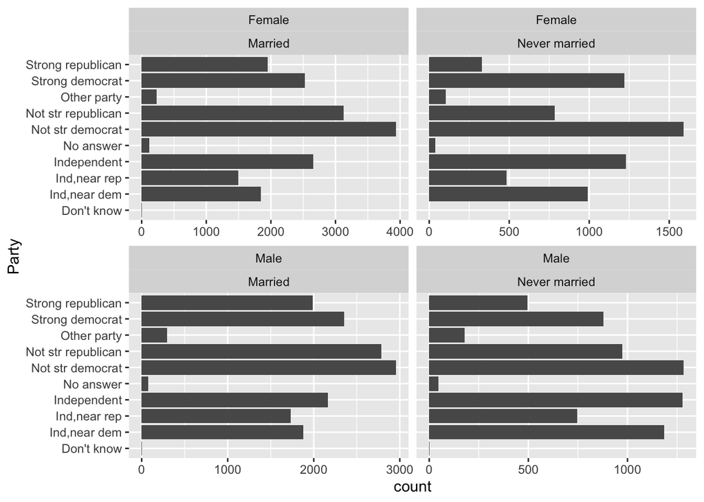

```r
dat5<- dat
dat5 <- dat5[dat5$Marital == 'Married' | dat5$Marital == 'Never married',]
dat5$Marital <- factor(dat5$Marital)
ggplot(dat5, aes(x = Party)) + geom_bar() + coord_flip() + facet_wrap(Sex~Marital, scale = 'free_x')
```

The Party that all respondents answered at the highest rate was ‘Not Strong democrat’. Females that had never married had the lowest rate of all the demographics of being a strong republican. Married respondents tended to have a higher rate of being a strong republican than respondents that were never married. Males that were never married had the highest rate of being independent over all other demographics. Married males had the highest rate of not having a strong opinion on their political party. Overall the responses vary a lot between different genders and marital status’s.

7.) In the 21st century, how did the number of earners in a family relate to how many children that family had?

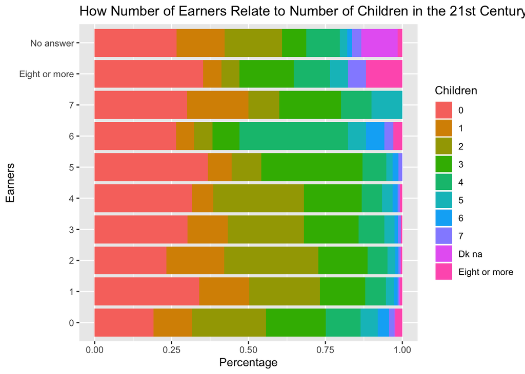

```r
dat21 <- dat[dat$Year >=2000, ]

ggplot(dat21, aes(Earners)) + geom_bar(aes(fill=Children), position=position_fill(reverse=TRUE)) +
  ggtitle("How Number of Earners Relate to Number of Children in the 21st Century") + ylab("Percentage") + coord_flip()
```

In the 21st century, this graph doesn’t appear to show a clear strong trend. Instead, it appears that the number of earners changes the size if the family in many different ways, with a few interesting trends to point out. Families with 1 earner have a much higher percentage of having 0 kids than families with 0 or 2 earners. This might be because these families cannot afford to have children on only one paycheck. It is also interesting to point out that across all earner marks, a higher percentage of families choose to have 0 kids than only have 1 kid. Most families appear to have multiple children once they start having children, regardless of number of earners. This is backed up by the low percentage of 1 children, 0 earner families. An odd trend to point out is the over 25% of respondents in 6 earner families with 4 children. This trend is not carried over by any other number of earners, and I’d be very curious to see why this is. It’s possible that all 4 children are earners in these families, and perhaps the added income is the reason for having these children in the first place.